# Classificação bayesiana dinâmica de proficiência em Biologia

Níveis tipo PAEBES atualizados ao longo do ano letivo

João Paulo Gusmão Teixeira

EST613 – Estatística Bayesiana · UFV

2026-11-30

## Contexto

- O PAEBES classifica os alunos em **Abaixo do Básico**, **Básico**, **Proficiente** e **Avançado**, mas é aplicado poucas vezes
- No dia a dia, a escola só tem **notas de 0 a 100**, que dependem da **escola de origem** e do **rigor do professor** (Zitzmann et al., 2025)
- A média simples pesa igual provas antigas e recentes e não informa a incerteza

## Pergunta e objetivo

> Como acessar mais rápidamente o nível de proeficiência dos alunos?

**Objetivo:** propor e avaliar um modelo bayesiano que classifique o padrão de desempenho dos alunos em Biologia a partir do seu histórico escolar e das notas ao longo do ano letivo.

# Metodologia

## Dados simulados

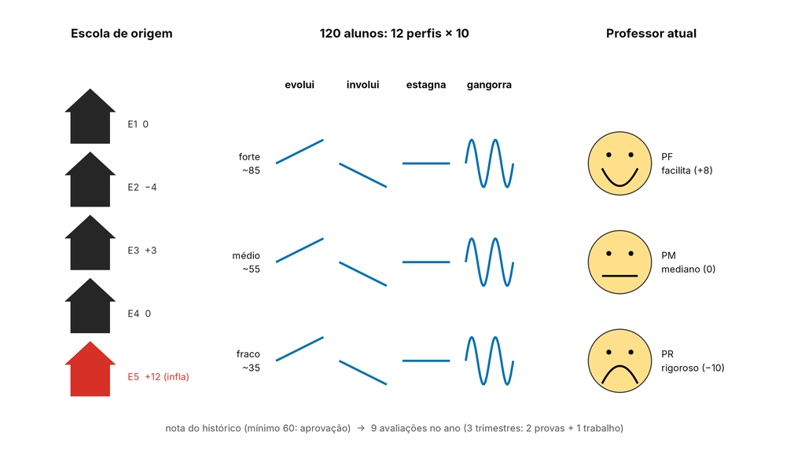

## O modelo em 5 passos

| Passo | M1: **fixos** $\sigma_0{=}10,\ \sigma{=}6,\ \omega{=}3$ | M2: **estimados** (Stan) |
| --- | --- | --- |
| **1. Parâmetro** | $\theta_{it}$ = proficiência real do aluno $i$ na prova $t$ (traço latente, 0–100) | igual |
| **2. Prior** (chegada) | $\theta_{i0} \sim N(h_i,\ \sigma_0^2)$ | $h_i \sim N(\theta_{i1} + \gamma_{e} + \delta_{p},\ \sigma_h^2)$; o 60 vale “≤ 60” |
| **3. Verossimilhança** | $y_{it} \mid \theta_{it} \sim N(\theta_{it},\ \sigma^2)$ | $y_{it} \mid \theta_{it} \sim N(\theta_{it} + \delta_{a},\ \sigma^2)$ |
| **+ Dinâmica** | $\theta_{it} = \theta_{i,t-1} + \eta,\ \ \eta \sim N(0,\ \omega^2)$ | igual |
| **4. Posteriori** | Normal, fórmula fechada (filtro de Kalman) | amostras MCMC (NUTS) |
| **5. Classificação** | probabilidade de cada faixa (cortes 40 / 60 / 80) | igual |

**Kalman:** a cada prova, a nova estimativa é uma média ponderada entre o que se achava antes e a nota nova; pesa mais a que tem menos incerteza.  
M0 = média simples das notas: sem prior e sem probabilidade.

## M1: valores fixados e por quê

| Termo | O que é | Valor | Por quê |
| --- | --- | --- | --- |
| $\sigma_0$ | incerteza da prior (histórico) | **10** | erro do histórico (5) + escola e professor de origem, que o M1 **não** desconta: $\sqrt{5^2+6^2+6^2}\approx 10$ |
| $\sigma$ | erro de medida de uma prova | **6** | é o erro usado na simulação |
| $\omega$ | quanto o aluno muda entre provas | **3** | tendências de ~2 a 2,5 pontos por avaliação + passeio aleatório (DP 2) |

Valores do **desenho da simulação**: favorece o M1, e mesmo assim o M2 classifica melhor.

## Como o modelo funciona

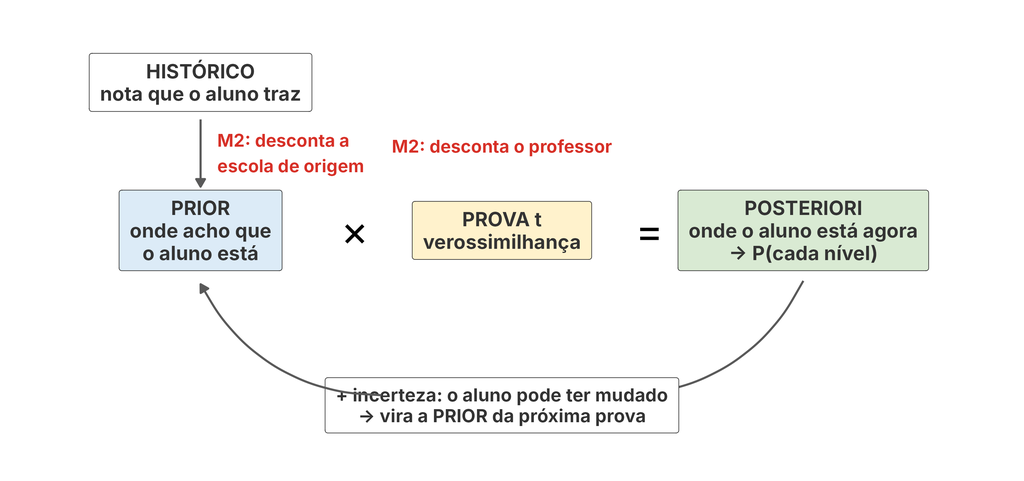

O histórico é a prior (Van Moere e Hanlon, 2020); cada prova atualiza; a posteriori vira a prior da próxima prova. O M2 corrige as notas pela escola e pelo professor.

## Distribuições e valores (M2)

| Parâmetro | Prior (o que assumimos) | Posterior (média) |
| --- | --- | --- |
| $\theta_{i1}$ proficiência na chegada | $N(50,\ 25^2)$ (vaga) | um valor por aluno |
| $\sigma$ erro das provas | half-Normal(0, 10) | **6,4** (real 6) |
| $\sigma_h$ erro do histórico | Gama(2; 0,2) | **4,0** (real 5) |
| $\omega$ mudança por prova | half-Normal(0, 5) | **3,8** (sem valor único: tendências + acaso) |
| $\gamma_e$ escola de origem | $N(0,\ \tau_{esc}^2)$ | E5: **+11,5** (real +12) |
| $\delta$ professor | $N(0,\ \tau_{prof}^2)$; atuais somam 0 | PR/PM/PF: **−9,1 / 0,9 / 8,3** (real −10 / 0 / 8)¹ |
| $\tau_{esc}$, $\tau_{prof}$ *(hiperparâmetros)* | half-Normal(0, 10) *(hiperpriori)* | **7,1** e **5,8** (real: ~6 entre escolas) |

¹ Efeito médio na nota: PR tira 10, PF dá 8. A estimativa é **relativa à média dos três** (soma zero): o real centrado seria −9,3 / 0,7 / 8,7.

**Total: 1.106 parâmetros** (1.080 $\theta_{it}$ + 26 globais e de grupo) para 1.200 observações · Sensibilidade: $\tau \sim$ half-Cauchy(0, 5) → mesmos resultados

## Verossimilhança

$$L = \prod_{i=1}^{120}\Big[\prod_{t=1}^{9}\phi(y_{it};\,\theta_{it}+\delta_{a(i)},\,\sigma^2)\Big]\times L_{h,i}$$

$$L_{h,i} =
\begin{cases}
\phi(h_i;\ \mu_{h,i},\ s_i^2) & \text{se } h_i > 60 \ \text{(nota observada)}\\
\Phi\big((60-\mu_{h,i})/s_i\big) & \text{se } h_i = 60 \ \text{(só se sabe que era} \le 60)^{*}
\end{cases}$$

$\mu_{h,i} = \theta_{i1}+\gamma_{e(i)}+\delta_{p(i)}$ · $s_i^2 = \sigma_h^2$ (prof. de origem conhecido) ou $\sigma_h^2+\tau_{\text{prof}}^2$ (desconhecido) · posterior $\propto L \times$ priors

## O ruído da dinâmica (filtro de Kalman)

1. **Previsão:** antes da prova, a incerteza **aumenta** ($v + \omega^2$): o aluno pode ter mudado
2. **Atualização:** Normal–Normal, média ponderada pelas precisões

|  | Peso da prova mais recente |
| --- | --- |
| Sem ruído ($\omega = 0$), 9ª avaliação | ~11% (≈ média simples) |
| Com ruído ($\omega = 3$) | **~39%** |

## Checagem preditiva a priori

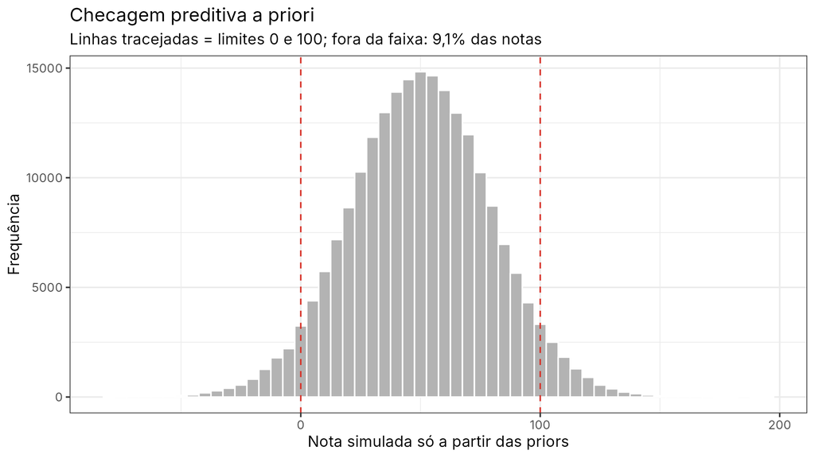

Escala certa, mas **9% das notas fora de 0–100**: as priors não conhecem o teto.

## Classificação = teste de hipóteses

- Cada nível é uma **região** do parâmetro: $\text{Básico} = \{40 < \theta_{it} \le 60\}$
- $P(\text{Básico} \mid \text{dados})$ = proporção de amostras do MCMC na faixa (como as probabilidades de desempenho superior de Dias et al., 2022)
- Regras: nível mais provável × **troca só se $P > 0{,}7$**

# Resultados

## M2: o caminho até o modelo final

| Tentativa | Div. | R-hat | δ PR / PM / PF |
| --- | --- | --- | --- |
| 1 · sem restrição | **9** | 1,02 | −5,5 / 4,3 / 12,0 |
| 2 · + soma zero | 0 | 1,01 | −9,1 / 0,9 / 8,2 |
| 3 · + Gama em $\sigma_h$ | 0 | 1,01 | −9,1 / 0,8 / 8,2 |
| 3 · com half-Cauchy | 0 | 1,02 | −9,1 / 1,0 / 8,1 |
| **4 · + δ não centrado** | **1** | **1,01** | **−9,1 / 0,9 / 8,3** |
| *verdadeiro* |  |  | *−10 / 0 / 8* |

**Tentativa 1 = modelo não identificável**, como $y = \mu + \tau_i + e$: somar 4 a $\theta$ e tirar 4 de $\delta$ dá o mesmo ajuste → restrição $\sum \delta = 0$.

## Convergência do modelo final

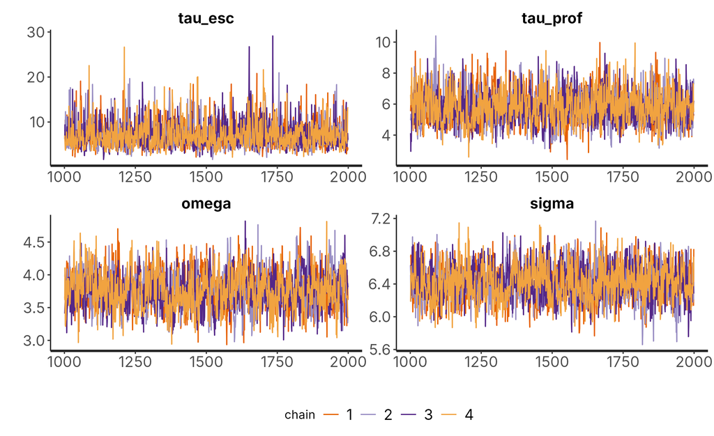

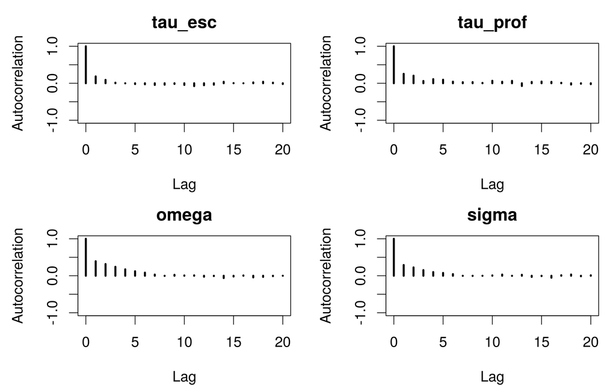

| Diagnóstico | Resultado |
| --- | --- |
| Traço (4 cadeias) | misturadas, sem tendência |
| Gelman–Rubin | ≤ 1,01 |
| Autocorrelação | ~0 antes do lag 10 → sem thin |
| ESS · MCSE | > 540 · ≤ 0,07 ponto |

| Diagnóstico | Resultado |
| --- | --- |
| Geweke (\|z\| > 1,96) | 5 de 52 (acaso ≈ 2,6) |
| Heidelb.–Welch | aprovado |
| Raftery–Lewis | não se aplica |
| half-Cauchy | o mesmo (Geweke 10 de 52) |

## O modelo reproduz os dados?

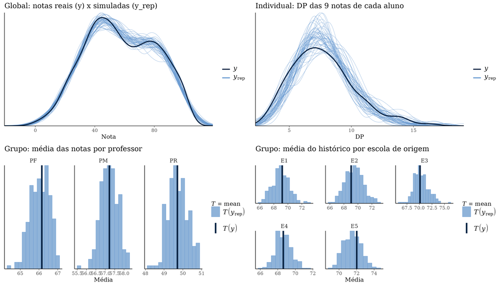

p bayesiano entre 0,17 e 0,66 nos três níveis · exceção: **máximo (p = 1,00)**, notas acima de 100

## Comparação de modelos (sem usar a verdade)

**Chegou um aluno novo: o modelo prevê bem as notas dele?**

| Modelo | DIC | LOOIC por aluno |
| --- | --- | --- |
| **M2 completo** | **7.835** | **8.426** |
| M2 sem escola e professor | 7.939 | 8.508 |

Diferença de ELPD = 41,1 (EP 7,6) · o completo prevê melhor **93 de 120** alunos

## Trajetórias estimadas

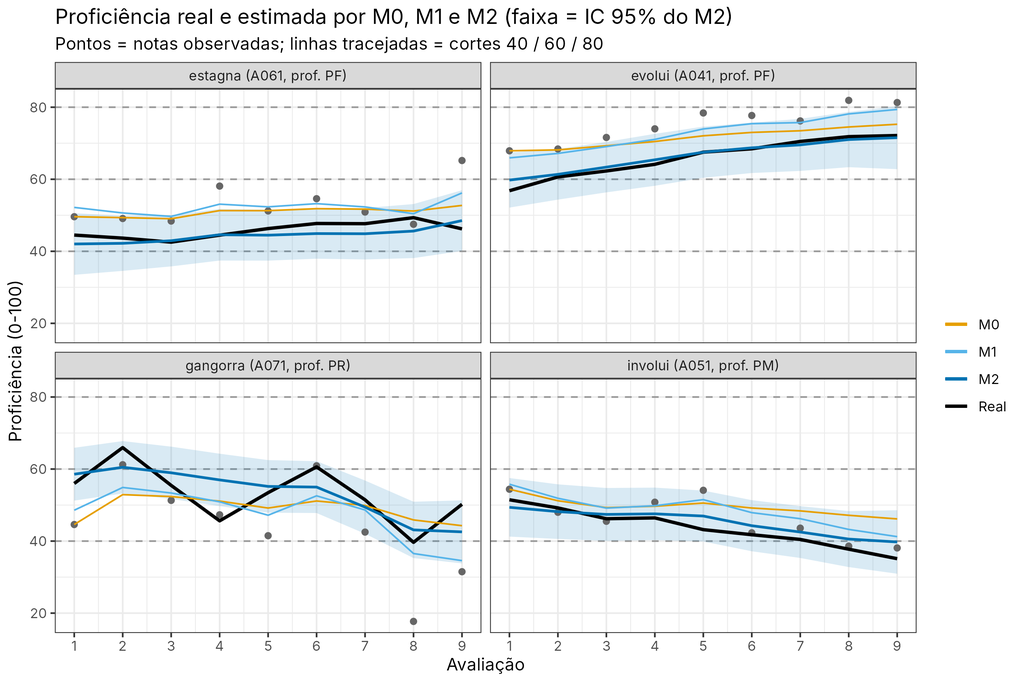

## Um aluno de cada perfil

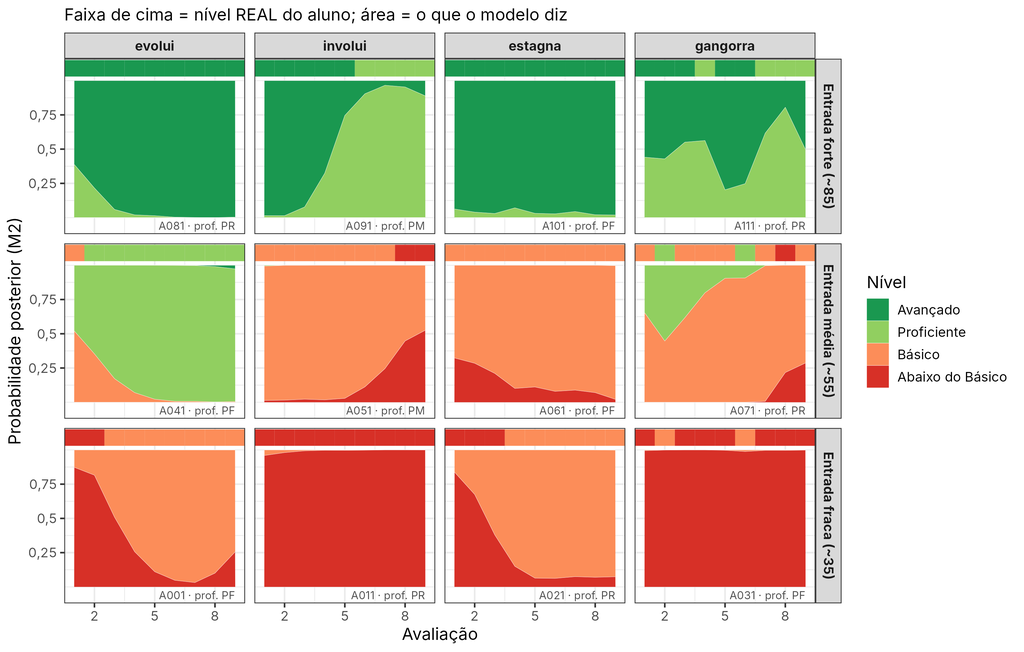

## Desempenho da classificação

| Modelo | Acerto | Trocas/aluno | Mudanças não detectadas |
| --- | --- | --- | --- |
| M0 · média simples | 66,4% | 0,58 | 48,1% |
| M1 · limiar 0,7 | 67,9% | 0,62 | 38,3% |
| **M2 · limiar 0,7** | **82,8%** | 0,36 | 39,5% |
| M2 · maior probabilidade | 84,7% | 0,60 | 30,9% |

Trocas reais: 1,55 por aluno · 81 de 120 alunos mudam de nível

## O rigor do professor importa

| Professor atual | M0 | M1 | **M2** |
| --- | --- | --- | --- |
| PR · rigoroso (−10) | 55,3% | 59,1% | **79,2%** |
| PM · mediano (0) | 79,2% | 79,0% | **85,3%** |
| PF · flexível (+8) | 61,7% | 63,0% | **83,3%** |

Acerto da classificação (regra do limiar 0,7)

Prior viesada não ajuda (Zitzmann et al., 2025): o M1 usa o histórico **sem ajuste** e fica perto da média simples

## Efeitos e teste de hipóteses

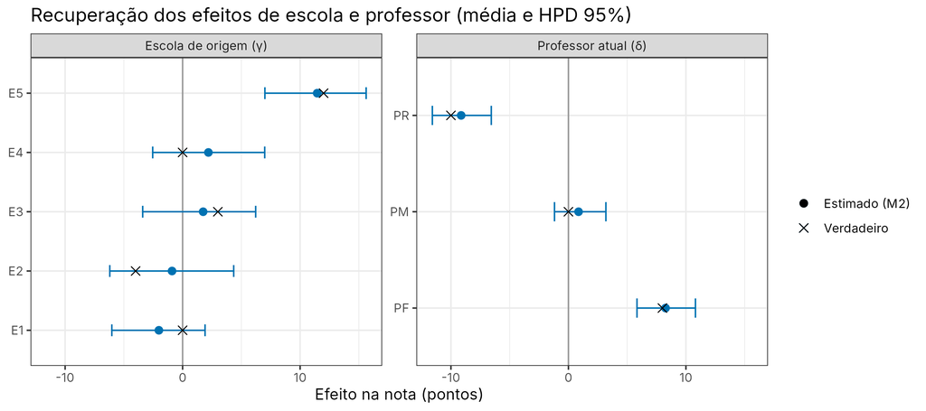

$P(\delta_{\text{PR}} < 0 \mid y) = 1{,}00$ · $P(\delta_{\text{PF}} > 0 \mid y) = 1{,}00$ · PM: $P(|\delta| < 2 \mid y) = 0{,}84$ (ROPE)

## Partial pooling

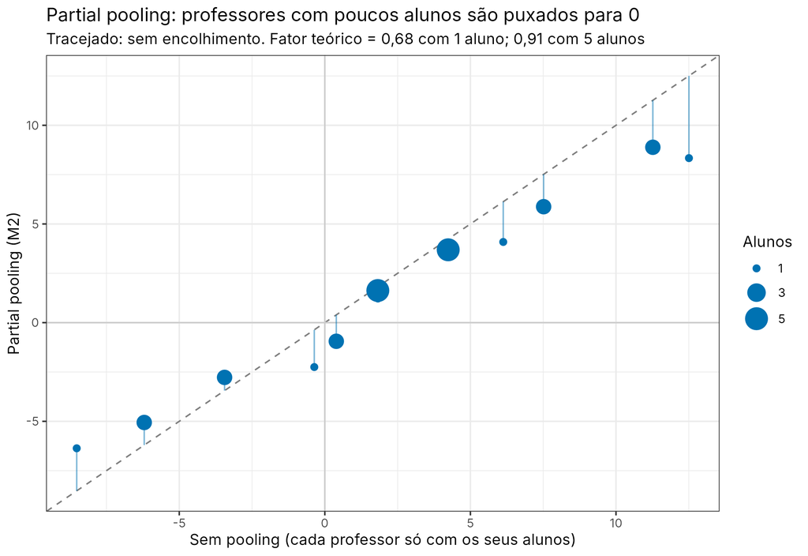

Fator de encolhimento $= \tau^2 / (\tau^2 + \sigma_h^2/n)$: **0,68** com 1 aluno → **0,91** com 5

# Conclusão

## Conclusão

- O modelo bayesiano dinâmico **classifica melhor** que a média simples (83% × 66%)
- O ganho vem de **estimar o rigor do professor e a escola de origem**, confirmado pelo DIC e pelo LOO
- A dinâmica **acompanha quem melhora ou piora**
- **Limitação:** notas **censuradas em 100**, tratadas como normais (convergiu e é o melhor, mas ainda não é perfeito)
- **Perspectiva:** dados reais da Sedu
  - histórico do 6º ao 9º ano → prior do 1º ano = posteriori do fim do EF
  - PAEBES como régua externa → **prever o nível do aluno no PAEBES**

## Referências

- Carpenter, B. et al. (2017). Stan: a probabilistic programming language. *Journal of Statistical Software*, 76(1).
- Dias, K. O. G. et al. (2022). Leveraging probability concepts for cultivar recommendation in multi-environment trials. *Theoretical and Applied Genetics*, 135, 1385–1399.
- Gelman, A. (2006). Prior distributions for variance parameters in hierarchical models. *Bayesian Analysis*, 1(3), 515–534.
- Kalman, R. E. (1960). A new approach to linear filtering and prediction problems. *Journal of Basic Engineering*, 82(1), 35–45.
- Kaplan, D. et al. (2023). Bayesian dynamic borrowing of historical information with applications to the analysis of large-scale assessments. *Psychometrika*, 88(1), 1–30.
- Spiegelhalter, D. J. et al. (2002). Bayesian measures of model complexity and fit. *JRSS B*, 64(4), 583–639.
- Van Moere, A.; Hanlon, S. (2020). A Bayesian approach to improving measurement precision over multiple test occasions. *Language Testing*, 37(4), 482–502.
- Vehtari, A.; Gelman, A.; Gabry, J. (2017). Practical Bayesian model evaluation using LOO-CV and WAIC. *Statistics and Computing*, 27, 1413–1432.
- Zitzmann, S. et al. (2025). Novick meets Bayes: improving the assessment of individual students in educational practice and research by capitalizing on assessors’ prior beliefs. *Educational and Psychological Measurement*, 85(3), 483–506.